# Tarea_3

Autor/a

Daniela Moya Víquez

# 1. Introducción

## 1.1. Indice de calor

El índice de calor es la sensación térmica que experimenta el cuerpo humano al combinar la temperatura del aire y la humedad relativa. Para estimarla, se requieren dos variables principales (Decreto N.º 39147-S-TSS, 2015):

1. Temperatura del aire (en grados Celsius o Fahrenheit).
2. Humedad relativa (en porcentaje %).

De conformidad con el estudio realizado por la Caja Costarricense de Seguro Social, denominado *“Factores Asociados a Enfermedad Renal Crónica, Región Chorotega año 2014”*, se concluye que en Costa Rica, la ERCnT tiende a ser mayor en hombres jóvenes que se dedican a trabajos físicos y se concentran en comunidades de la provincia de Guanacaste (Caja Costarricense de Seguro Social [CCSS], 2014)

La enfermedad renal crónica de origen no tradicional (ERCnT) es una patología desencadenada principalmente por el estrés térmico ocupacional. Estudios recientes han demostrado cambios en la función renal y en los biomarcadores de hidratación en el curso de los turnos laborales, así como una disminución de la función renal relacionada con el calor y la carga de trabajo (Wesseling et al., 2020).

Ante esta problemática de salud ocupacional, este documento permite estimar el **índice de calor** a nivel territorial utilizando la base de datos de WorldClim descargada mediante el paquete `geodata` de forma mensual (contiene 12 capas, una para cada mes del año). Cabe destacar que estos datos no corresponden a un año específico reciente, sino que representan una climatología histórica promedio calculada entre los años 1970 y 2000.

WorldClim no proporciona la humedad relativa (HR) directamente, pero sí provee la presión de vapor real (*vap*), la cual, combinada con la temperatura máxima (*tmax*) y mínima (*tmin*), permite calcular la humedad relativa mediante una aproximación termodinámica estandarizada por la Organización Meteorológica Mundial (OMM, s.f.).

> *Nota metodológica: Dado que esta ecuación requiere constantes complejas y factores de corrección adicionales cuando la temperatura o la humedad alcanzan umbrales extremos, se delegó su ejecución algorítmica a la función `heat.index()` del paquete `weathermetrics`. Esta función automatiza el cálculo matemático garantizando precisión al convertir y procesar directamente los valores en grados Celsius.*

## 1.2. Datos geoespaciales

Se integraron los datos climáticos históricos de WorldClim (procesados previamente en formato tabular para extraer la temperatura máxima y la presión de vapor) con la capa vectorial de la división territorial administrativa de Costa Rica.

Esta capa geoespacial corresponde a los cantones del país, generada oficialmente por el Instituto Geográfico Nacional (IGN) y disponible en el repositorio de datos del curso en formato GeoPackage. Desde el punto de vista técnico, la capa se describe de la siguiente manera:

- **Geometría:** conformada por MultiPolígonos que delimitan las 84 entidades territoriales cantonales vigentes.
- **Sistema de Referencia de Coordenadas (SRC):** su proyección nativa es **CRTM05 (EPSG:8908)**, el estándar cartográfico oficial de Costa Rica.
- **Atributos principales:** contiene las columnas `provincia` y `canton`, las cuales resultan esenciales para funcionar como “llaves” durante la unión tabular (`left_join`) con la base de datos climatológica.

**Preguntas a responder en este documento:**

1. ¿Cuándo es más peligroso?, meses del año con más exposición al calor en C.R.
2. ¿Dónde es más peligroso?, provincia con más exposción al calor en C.R.
3. ¿Cuál es el Nivel de Riesgo de todos los cantones del país?
4. ¿Cuáles son los 15 cantones más afectados a nivel nacional?
5. Ante esta problemática de salud ocupacional, se plantea la siguiente interrogante espacial: ¿En cuáles cantones de Costa Rica se concentran los niveles de riesgo de estrés térmico más severos (Niveles III y IV, según la categorización de la OSHA) durante las jornadas laborales diurnas?*

# 2. Importación y preparación de los datos

## 2.1. Carga de paquetes

**Ver código**

```r
library(sf)
library(readr)
library(dplyr)
library(tidyr)
library(ggplot2)
library(plotly)
library(DT)
library(weathermetrics)
library(geodata)
library(leaflet)
```

## 2.2. Directorio de datos en el repositorio del curso

**Ver código**

```r
# Cargar geometrías base en WGS84

datos <- "https://raw.githubusercontent.com/pf0953-programacionr/2026-ii/main/datos/"
cantones <- st_read(paste0(datos, "cantones.gpkg"), quiet = TRUE) |>
  st_transform(4326)
provincias <- st_read(paste0(datos, "provincias.gpkg"), quiet = TRUE) |>
  st_transform(4326)
```

## 2.3.Descarga de datos del clima para Costa Rica

**Ver código**

```r
# Descarga GLOBAL
ruta_clima <- "datos_clima"
dir.create(ruta_clima, showWarnings = FALSE)

tmax_global <- worldclim_global(var = "tmax", res = 2.5, path = ruta_clima)
tmin_global <- worldclim_global(var = "tmin", res = 2.5, path = ruta_clima)
vap_global  <- worldclim_global(var = "vapr", res = 2.5, path = ruta_clima)
```

## 2.4. Recortar a Costa Rica

**Ver código**

```r
# Recortar manualmente (crop) a la extensión de Costa Rica

bbox_cr <- ext(-86.5, -82.0, 8.0, 11.5)

tmax_cr <- crop(tmax_global, bbox_cr)
tmin_cr <- crop(tmin_global, bbox_cr)
vap_cr  <- crop(vap_global, bbox_cr)
```

## 2.5.Extracción espacial hacia polígonos

**Ver código**

```r
# Extracción espacial
cantones_vect <- vect(cantones)

# Extraemos las 12 capas mensuales
temp_tmax <- extract(tmax_cr, cantones_vect, fun = mean, na.rm = TRUE)
temp_tmin <- extract(tmin_cr, cantones_vect, fun = mean, na.rm = TRUE)
temp_vap  <- extract(vap_cr, cantones_vect, fun = mean, na.rm = TRUE)
```

## 2.6. Nombrar los meses

**Ver código**

```r
# Quitar la columna ID y nombramos las columnas con los meses
ext_tmax <- temp_tmax |> select(-ID)
ext_tmin <- temp_tmin |> select(-ID)
ext_vap  <- temp_vap |> select(-ID)

meses <- c("Ene", "Feb", "Mar", "Abr", "May", "Jun", "Jul", "Ago", "Sep", "Oct", "Nov", "Dic")
colnames(ext_tmax) <- paste0("Tmax_", meses)
colnames(ext_tmin) <- paste0("Tmin_", meses)
colnames(ext_vap)  <- paste0("Vap_", meses)
```

## 2.7. Base de datos final-mensual

**Ver código**

```r
# Tabla (Tidy) quitando la geometría

tabla_final_mensual <- cantones |>
  st_drop_geometry() |>
  select(provincia, canton) |>
  bind_cols(ext_tmax, ext_tmin, ext_vap)
```

## 2.8 Importar datos desde el URL (BD:tabla_final_mensual)

**Ver código**

```r
# Datos desde el RAW en GitHub

url_datos <- "https://raw.githubusercontent.com/dani10movister-bot/tarea-03/refs/heads/main/clima_costa_rica_mensual.csv"
datos_crudos <- read_csv(url_datos, show_col_types = FALSE)
```

## 2.9. Transformación de datos y estimación de variables termodinámicas

**Ver código**

```r
# Transformación y limpieza de datos
datos_calor <- datos_crudos |>

# Pasar de 12 columnas mensuales a filas, separando la variable del mes
  pivot_longer(
    cols = -c(provincia, canton),
    names_to = c(".value", "Mes"),
    names_sep = "_"
  ) |>

# Filtrar los NA para que heat.index no colapse
  filter(!is.na(Tmax) & !is.na(Vap)) |>

# Cálculo de variables termodinámicas
  mutate(T_Med = (Tmax + Tmin) / 2,
    es = 0.6108 * exp((17.27 * T_Med) / (T_Med + 237.3)),
    Humedad = (Vap / es) * 100,
    Humedad = ifelse(Humedad > 100, 100, Humedad),
    Indice_Calor = heat.index(t = T_Med, rh = Humedad, temperature.metric = "celsius", output.metric = "celsius", round = 1),
    Mes = factor(Mes, levels = c("Ene", "Feb", "Mar", "Abr", "May", "Jun", "Jul", "Ago", "Sep", "Oct", "Nov", "Dic")))
```

# 3. Análisis Territorial del IC

El estrés térmico requiere un análisis que combine la dimensión temporal **(¿cuándo es más peligroso?)** y la dimensión territorial **(¿dónde es más peligroso?)**. A continuación, se presentan visualizaciones interactivas para responder ambas preguntas.

## 3.1 Evolución Temporal

Para identificar la ventana temporal de mayor vulnerabilidad, se agrupan los datos por mes y se calcula el Índice de Calor promedio a nivel nacional.

## 3.1.1. Evolución mensual del Índice de Calor: meses críticos de calor en Costa Rica

**Ver código**

```r
#  Preparación de datos (dplyr)
resumen_mensual <- datos_calor |>
  group_by(Mes) |>
  summarize(
    Indice_Promedio = round(mean(Indice_Calor, na.rm = TRUE), 1),
    Hum_Promedio = round(mean(Humedad, na.rm = TRUE), 1)
  )
# Creación del gráfico base (ggplot2)
g_lineas <- ggplot(resumen_mensual, aes(x = Mes, y = Indice_Promedio, group = 1)) +
  geom_line(color = "firebrick", linewidth = 1) +
  # Se añade 'text' para enriquecer la ventana emergente de plotly
  geom_point(aes(text = paste("Humedad:", Hum_Promedio, "%")), color = "darkorange", size = 2.5) +
  labs(
    title = "Evolución Mensual del Índice de Calor (Promedio Nacional)",
    x = "Mes del Año",
    y = "Índice de Calor (°C)"
  ) +
  theme_minimal()

# Convertir a gráfico interactivo (plotly)
ggplotly(g_lineas, tooltip = c("x", "y", "text"))
```

[interactive chart not shown]

Figura 1: Evolución Mensual del Índice de Calor (Promedio Nacional)

Tal y como se observa en el Figura 1, los meses de más peligro en Costa Rica para los colaboradores , principalmente los que trabajan en exteriores de acuerdo a los datos promedio de Evolución mensual de calor,los meses de marzo, abril y mayo son los meses más calientes, siendo abril el mes con la sensación térmica más extrema.

## 3.1.2. Dimensión territorial: provincia más vulnerable según el IC

**Ver código**

```r
# Agrupación y orden por provincia
resumen_provincia <- datos_calor |>
  group_by(provincia) |>
  summarize(Indice_Anual = round(mean(Indice_Calor, na.rm = TRUE), 1)) |>
  arrange(desc(Indice_Anual)) |>

  # reorder(): ggplot ordena de mayor a menor
  mutate(provincia = reorder(provincia, Indice_Anual))

# Gráfico de barras horizontales
g_barras <- ggplot(resumen_provincia, aes(x = Indice_Anual, y = provincia, fill = Indice_Anual)) +
  geom_col() +
  scale_fill_viridis_c(option = "magma", direction = -1) +
  labs(
    title = "Índice de calor promedio anual por provincia",
    x = "Índice de Calor (°C)",
    y = ""
  ) +
  theme_minimal() +
  theme(legend.position = "none")

# Interactividad del gráfico
ggplotly(g_barras, tooltip = c("x", "y"))
```

[interactive chart not shown]

Figura 2: Índice de calor promedio anual por provincia

El análisis territorial por provincias del Figura 2 permite observar que las regiones costeras y de bajura, particularmente en el Pacífico, concentran las condiciones termodinámicas más extremas, siendo Guanacaste la región más expuesta al peligro por exposición al calor. Lo cual coincide con el estudio realizado por la Caja Costarricense de Seguro Social.

## 3.1.3. Relación Termodinámica (Temperatura vs. Humedad)

Considerando que los umbrales oficiales de la OSHA (Administración de Seguridad y Salud Ocupacional), dictan que los colores cambian en los siguientes valores de Nivel de Riesgo de acuerdo al Índice de Calor:

- Nivel I (Verde): Menor a 32.8 °C (Precaución).
- Nivel II (Amarillo): 32.8 °C a 39.4 °C (Precaución extrema).
- Nivel III (Naranja): 39.4 °C a 46.1 °C (Peligro).
- Nivel IV (Rojo): Mayor a 46.1 °C (Peligro extremo).

## 3.1.3.1. Asignación de Nivel de Riesgo del IC

**Ver código**

```r
datos_calor <- datos_crudos |>
  pivot_longer(
    cols = -c(provincia, canton),
    names_to = c(".value", "Mes"),
    names_sep = "_"
  ) |>
  filter(!is.na(Tmax) & !is.na(Vap)) |>
  mutate(

# Usando T_Med solo para la fórmula termodinámica de humedad
    T_Med = (Tmax + Tmin) / 2,
    es = 0.6108 * exp((17.27 * T_Med) / (T_Med + 237.3)),
    Humedad = (Vap / es) * 100,
    Humedad = ifelse(Humedad > 100, 100, Humedad),

# Estimación del Nivel de Riesgo por IC usando la Tmax (jornada laboral diurna)
    Indice_Calor = heat.index(t = Tmax, rh = Humedad, temperature.metric = "celsius", output.metric = "celsius", round = 1),

    Mes = factor(Mes, levels = c("Ene", "Feb", "Mar", "Abr", "May", "Jun", "Jul", "Ago", "Sep", "Oct", "Nov", "Dic")),

    # Clasificación OSHA con los datos corregidos
    Nivel_Riesgo = cut(
      Indice_Calor,
      breaks = c(-Inf, 32.8, 39.4, 46.1, Inf),
      labels = c("Nivel I", "Nivel II", "Nivel III", "Nivel IV"),
      right = FALSE
    )
  )
```

## 3.1.3.1. Identificación del Nivel de Riesgo en un gráfico de dispersión

Este gráfico permitirá identificar el nivel de riesgo de todos los cantones del país, de acuerdo a los Niveles de Riesgo (OSHA) recomendados por el CSO.

**Ver código**

```r
# Definir los colores exactos de la matriz OSHA
colores_osha <- c(
  "Nivel I" = "#9bc86e",   # Verde
  "Nivel II" = "#fcf27c",  # Amarillo
  "Nivel III" = "#eb7f35", # Naranja
  "Nivel IV" = "#e33224"   # Rojo
)

# Gráfico de dispersión por categoría
g_dispersion <- ggplot(datos_calor, aes(
    x = T_Med,
    y = Humedad,
    color = Nivel_Riesgo,
    text = paste("Cantón:", canton, "<br>Índice:", Indice_Calor, "°C")
  )) +
  geom_point(alpha = 0.8, size = 2.5) +

# Paleta de colores personalizada
  scale_color_manual(values = colores_osha) +
  labs(
    title = "Relación Termodinámica y Niveles de Riesgo (OSHA)",
    x = "Temperatura Media (°C)",
    y = "Humedad Relativa (%)",
    color = "Nivel de Riesgo"
  ) +
  theme_minimal()

# Gráfico interactivo
ggplotly(g_dispersion, tooltip = c("text", "x", "y"))
```

[interactive chart not shown]

Figura 3: Relación Termodinámica y Niveles de Riesgo (OSHA)

## 3.1.4. Zonas de Intervención Prioritaria

A continuación, se muestran los 15 cantones del país con más alto riesgo a estrés térmico por calor, y por tanto posiblemente vulnerables a la ERCnt.

La siguiente tabla interactiva detalla los cantones donde la inspección y aplicación de los umbrales de seguridad establecidos por el CSO debe ser de carácter obligatorio, para velar por la salud de los colaboradores.

**Ver código**

```r
# Resumen anual por cantón
tabla_cantones_criticos <- datos_calor |>
  group_by(canton, provincia) |>
  summarize(
    Temp_Media = round(mean(T_Med, na.rm = TRUE), 1),
    Hum_Media = round(mean(Humedad, na.rm = TRUE), 1),
    Indice_Anual = round(mean(Indice_Calor, na.rm = TRUE), 1),
    .groups = "drop"
  ) |>
  arrange(desc(Indice_Anual)) |>
  # Seleccionar los 15 cantones más calientes (IC)
  slice_head(n = 15) |>
  rename(
    Cantón = canton,
    Provincia = provincia,
    `T. Media (°C)` = Temp_Media,
    `Humedad (%)` = Hum_Media,
    `Índice (°C)` = Indice_Anual
  )

# Tabla interactiva con DT
datatable(
  tabla_cantones_criticos,
  options = list(
    pageLength = 10,

# Configuración idioma español
    language = list(url = '//cdn.datatables.net/plug-ins/1.10.11/i18n/Spanish.json')
  ),
  rownames = FALSE
)
```

| Cantón | Provincia | T. Media (°C) | Humedad (%) | Índice (°C) |
| --- | --- | --- | --- | --- |
| Carrillo | Guanacaste | 27.2 | 76.3 | 44.1 |
| Nicoya | Guanacaste | 26.2 | 79.4 | 43.1 |
| Santa Cruz | Guanacaste | 26.6 | 77.6 | 43.1 |
| Nandayure | Guanacaste | 26 | 80.7 | 43 |
| Orotina | Alajuela | 26.1 | 81.8 | 42.8 |
| Garabito | Puntarenas | 26 | 82.8 | 42.4 |
| Esparza | Puntarenas | 26.1 | 82 | 42.3 |
| Quepos | Puntarenas | 25.6 | 84.2 | 42.1 |
| Osa | Puntarenas | 25.6 | 85.5 | 42 |
| Parrita | Puntarenas | 25.7 | 83.9 | 42 |

[output cut: 5 more lines]

Figura 4: Cantones del país con más alto riesgo a estrés térmico por calor

Tal como se aprecia en la Figura 4, se corrobora de nuevo que los cantones de la provincia de Guanacaste son de los más afectados, siendo Carrillo, Nicoya, Santa Cruz y Nandayure los primeros lugares de acuerdo al índice de calor con valores entre los 43 y 44°C.

# 4. Datos geoespaciales

## 4.1. Cálculo de IC diurno (ajuste de datos de las tablas)

**Ver código**

```r
# Cálculo termodinámico (usando Tmax para riesgo diurno)
datos_clima <- read_csv("https://raw.githubusercontent.com/dani10movister-bot/tarea-03/refs/heads/main/clima_costa_rica_mensual.csv", show_col_types = FALSE) |>
  pivot_longer(
    cols = -c(provincia, canton),
    names_to = c(".value", "Mes"),
    names_sep = "_"
  ) |>
  filter(!is.na(Tmax) & !is.na(Vap)) |>
  mutate(
    T_Med = (Tmax + Tmin) / 2,
    es = 0.6108 * exp((17.27 * T_Med) / (T_Med + 237.3)),
    Humedad = (Vap / es) * 100,
    Humedad = ifelse(Humedad > 100, 100, Humedad),
    Indice_Calor = heat.index(t = Tmax, rh = Humedad, temperature.metric = "celsius", output.metric = "celsius", round = 1)
  )
```

## 4.2. Resumen del IC máximo por cantón

**Ver código**

```r
# IC máximo por cantón
resumen_canton <- datos_clima |>
  group_by(canton) |>
  summarize(
    Indice_Maximo = max(Indice_Calor, na.rm = TRUE),
    .groups = "drop"
  ) |>
  mutate(
    Nivel_Riesgo = cut(
      Indice_Maximo,
      breaks = c(-Inf, 32.8, 39.4, 46.1, Inf),
      labels = c("Nivel I (Verde)", "Nivel II (Amarillo)", "Nivel III (Naranja)", "Nivel IV (Rojo)"),
      right = FALSE
    )
  )
```

## 4.3. Unión Espacial

Para cumplir con la unión espacial, se vincula la información climática (procesada tabularmente) con la división territorial cartográfica. Para esto, se ejecuta una unión tabular mediante la función `left_join()`.

Se utiliza el objeto espacial (`cantones`) a la izquierda para garantizar que el resultado herede la geometría (`sf`) y no se degrade a un marco de datos. La llave de unión seleccionada es la columna nominal `canton`.

**Ver código**

```r
# Unión de la capa vectorial con el resumen del Índice de Calor
mapa_riesgo <- cantones |>
  left_join(resumen_canton, by = "canton")

# Comprobar entidades sin coincidencias
cantones_sin_datos <- cantones |>
  anti_join(resumen_canton, by = "canton")
```

# 5. Visualización Espacial del Riesgo Térmico

Para visualizar la distribución espacial del riesgo térmico diurno a nivel nacional, se elabora un mapa de coropletas. Aunque la base de datos espacial fue transformada a WGS84 para compatibilidad web, el renderizado de este mapa estático se reproyecta al vuelo utilizando coord_sf(crs = 8908), aplicando el sistema oficial CRTM05 para minimizar la distorsión territorial de Costa Rica.

## 5.1. Mapa temático estático

**Ver código**

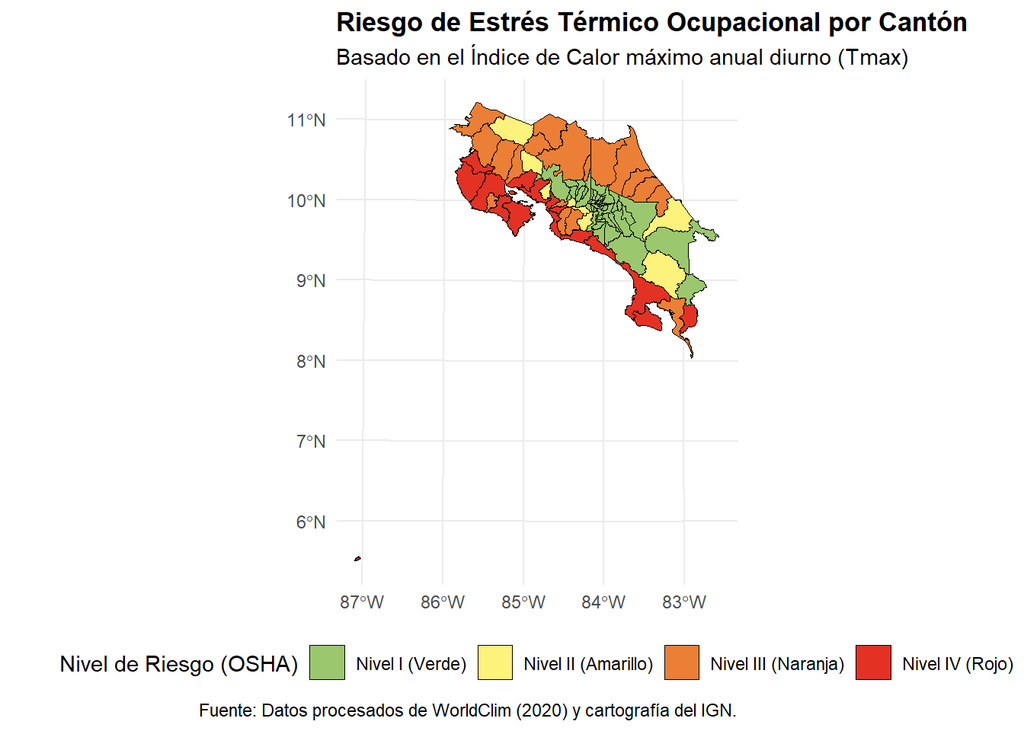

Figura 5: Mapa de distribución territorial del riesgo máximo de estrés térmico en Costa Rica.

```r
colores_mapa <- c(
  "Nivel I (Verde)" = "#9bc86e",
  "Nivel II (Amarillo)" = "#fcf27c",
  "Nivel III (Naranja)" = "#eb7f35",
  "Nivel IV (Rojo)" = "#e33224"
)

mapa_estatico <- ggplot(data = mapa_riesgo) +
  geom_sf(aes(fill = Nivel_Riesgo), color = "black", linewidth = 0.1) +
  scale_fill_manual(
    values = colores_mapa,
    na.value = "gray80",
    name = "Nivel de Riesgo (OSHA)"
  ) +
  coord_sf(crs = 8908) +
  labs(
    title = "Riesgo de Estrés Térmico Ocupacional por Cantón",
    subtitle = "Basado en el Índice de Calor máximo anual diurno (Tmax)",
    caption = "Fuente: Datos procesados de WorldClim (2020) y cartografía del IGN."
  ) +
  theme_minimal() +
  theme(legend.position = "bottom", plot.title = element_text(face = "bold"))

mapa_estatico
```

## 5.2. Mapa interactivo (Leaflet)

Para complementar el análisis estático, se presenta un mapa web interactivo en proyección WGS84, lo que permite la navegación fluida e inspección individual de los atributos de cada cantón.

## 5.2.1. Selección de color (Nivel de Riesgo IC)

**Ver código**

```r
# Paleta de colores para Leaflet
paleta_riesgo <- colorFactor(
  palette = c("#9bc86e", "#fcf27c", "#eb7f35", "#e33224"),
  domain = mapa_riesgo$Nivel_Riesgo
)
```

## 5.2.2. Configuración de etiquetas emergentes

**Ver código**

```r
etiquetas <- paste0(
  "<strong>Cantón: </strong>", mapa_riesgo$canton, "<br>",
  "<strong>Índice Máximo: </strong>", mapa_riesgo$Indice_Maximo, " °C<br>",
  "<strong>Riesgo OSHA: </strong>", mapa_riesgo$Nivel_Riesgo
) |> lapply(htmltools::HTML)
```

## 5.2.3. Mapa Interactivo

**Ver código**

```r
# Renderizar el mapa
leaflet() |>

  # Mapa base
    addProviderTiles(providers$OpenStreetMap, group = "OpenStreetMap") |>
  addProviderTiles(providers$Esri.WorldImagery, group = "Esri Satélite") |>

  # Capa temática (Polígonos)
  addPolygons(
    data = mapa_riesgo,
    fillColor = ~paleta_riesgo(Nivel_Riesgo),
    fillOpacity = 0.8,
    color = "black", # Borde de los cantones
    weight = 1,
    label = etiquetas,
    group = "Riesgo Térmico"
  ) |>

  # Leyenda
  addLegend(
    position = "bottomright",
    pal = paleta_riesgo,
    values = mapa_riesgo$Nivel_Riesgo,
    title = "Niveles OSHA",
    opacity = 1
  ) |>

  # Control de capas
  addLayersControl(
    baseGroups = c("OpenStreetMap)", "Esri Satélite"),
    overlayGroups = c("Riesgo Térmico"),
    options = layersControlOptions(collapsed = FALSE)
  ) |>

  # Barra de escala métrica
  addScaleBar(position = "bottomleft", options = scaleBarOptions(imperial = FALSE))
```

[interactive chart not shown]

Figura 6: Mapa de distribución territorial interactiva del riesgo máximo de estrés térmico en Costa Rica.

# 6. Conclusiones y Limitaciones

## 6.2. Limitaciones del estudio

Es importante reconocer las limitaciones metodológicas de este análisis. En primer lugar, los datos geoespaciales utilizados (WorldClim) corresponden a una climatología histórica mensual (1970-2000), por lo que no capturan anomalías térmicas recientes, olas de calor extremas actuales o el impacto agudo del cambio climático en los últimos 20 años.

En segundo lugar, al promediar los datos a nivel cantonal, se omite la existencia de microclimas dentro de un mismo cantón, lo que significa que trabajadores en zonas geográficamente específicas podrían estar sometidos a condiciones de Nivel IV (Peligro Extremo) que el promedio cantonal diluye.

Finalmente, la humedad relativa fue estimada a partir de la presión de vapor mediante fórmulas termodinámicas estandarizadas, lo cual es una aproximación robusta pero carece de la precisión absoluta de mediciones higrométricas directas en campo.

# 7. Referencias Bibliográficas

Caja Costarricense de Seguro Social. (2014). *Factores asociados a enfermedad renal crónica, Región Chorotega: Informe final de resultados*. Ministerio de Salud de Costa Rica. https://www.ministeriodesalud.go.cr/index.php/biblioteca-de-archivos-left/documentos-ministerio-de-salud/tecno-ciencia/inventario-de-enfermedad-renal-cronica-no-tradicional-ercnt/estudios-de-ercnt-situacion-de-la-problematica-en-costa-rica/9654-factores-asociados-a-enfermedad-renal-cronica-region-chorotega-ccss/file

Organización Meteorológica Mundial. (s.f.). *Guía de instrumentos y métodos de observación, volumen I – Medición de variables meteorológicas* (OMM-N° 8). https://library.wmo.int/viewer/68714/?offset=#page=1&viewer=picture&o=bookmark&n=0&q=

Presidencia de la República, Ministerio de Salud, & Ministerio de Trabajo y Seguridad Social. (2015, 23 de septiembre). Decreto Ejecutivo Nº 39147-S-TSS: Reglamento para la contratación de servicios de medicina del trabajo y seguridad e higiene en el trabajo. *La Gaceta*, (185), Alcance 75. http://www.pgrweb.go.cr/scij/Busqueda/Normativa/Normas/nrm_texto_completo.aspx?param1=NRTC&nValor1=1&nValor2=80290

Wesseling, C., Glaser, J., Rodríguez-Guzmán, J., Weiss, I., Lucas, R., Peraza, S., Soares da Silva, A., Hansson, E., Johnson, R. J., Hogstedt, C., Wegman, D. H., & Jakobsson, K. (2020). Chronic kidney disease of non-traditional origin in Mesoamerica: a disease primarily driven by occupational heat stress. *Revista Panamericana de Salud Pública, 44*, e54. https://iris.paho.org/handle/10665.2/51826

# 8. Declaración de uso de IA

Para el desarrollo de esta tarea se utilizó el asistente de inteligencia artificial Gemini (Google) como apoyo al aprendizaje, explicar mensajes de error, desarrollo del código y dar formato APA 7 a las referencias, cumpliendo con los lineamientos del curso. Los resultados fueron revisados, verificados y adaptados por la persona autora.